# Project 1

Celeste Zinmon-Htet

09/17/2023

## Part 1: Explore data

```r
library(tidytuesdayR)
library(here)
library(tidyverse)

tuesdata <- tidytuesdayR::tt_load("2022-01-18")
chocolate <- tuesdata$chocolate

# tests if a directory named "data" exists locally
if (!dir.exists(here("data"))) {
  dir.create(here("data"))
}

# saves data only once (not each time you knit a R Markdown)
if (!file.exists(here("data", "chocolate.RDS"))) {
  url_csv <- "https://raw.githubusercontent.com/rfordatascience/tidytuesday/master/data/2022/2022-01-18/chocolate.csv"
  chocolate <- readr::read_csv(url_csv)

  # save the file to RDS objects
  saveRDS(chocolate, file = here("data", "chocolate.RDS"))

  chocolate <- readRDS(here("data", "chocolate.RDS"))
  as_tibble(chocolate)

  glimpse(chocolate)
}

glimpse(chocolate)
```

```
## Rows: 2,530
## Columns: 10
## $ ref                              <dbl> 2454, 2458, 2454, 2542, 2546, 2546, 2…
## $ company_manufacturer             <chr> "5150", "5150", "5150", "5150", "5150…
## $ company_location                 <chr> "U.S.A.", "U.S.A.", "U.S.A.", "U.S.A.…
## $ review_date                      <dbl> 2019, 2019, 2019, 2021, 2021, 2021, 2…
## $ country_of_bean_origin           <chr> "Tanzania", "Dominican Republic", "Ma…
## $ specific_bean_origin_or_bar_name <chr> "Kokoa Kamili, batch 1", "Zorzal, bat…
## $ cocoa_percent                    <chr> "76%", "76%", "76%", "68%", "72%", "8…
## $ ingredients                      <chr> "3- B,S,C", "3- B,S,C", "3- B,S,C", "…
## $ most_memorable_characteristics   <chr> "rich cocoa, fatty, bready", "cocoa, …
## $ rating                           <dbl> 3.25, 3.50, 3.75, 3.00, 3.00, 3.25, 3…
```

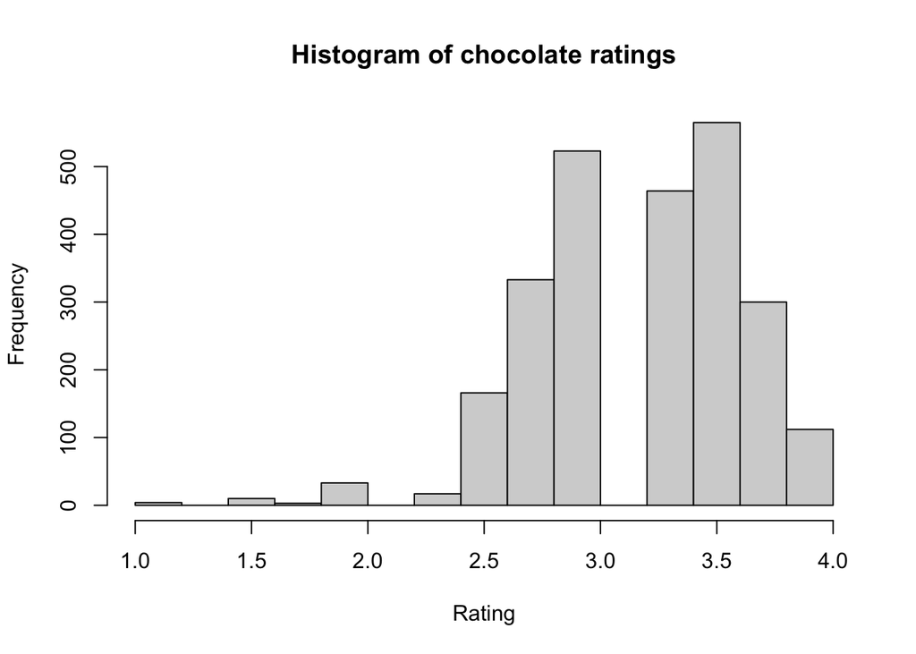

```r
hist(chocolate$rating, breaks=15,
     main = "Histogram of chocolate ratings",
     xlab = "Rating")
```

I chose to use 15 bins. When 10 breaks are specified, only 6 bins are produced. When 15 or 20 breaks are specified, 15 bins are produced. When 25 breaks are specified, 30 bins are produced. Different bin numbers than specified are due to R computing the closest number of bins possible. I picked 15, because the 25-break graph show many “empty” bins, and because the 10-break graph provides less information on actual ratings than the 15-break graph.

```r
table(chocolate$country_of_bean_origin)
```

```
##
##             Australia                Belize                 Blend
##                     3                    76                   156
##               Bolivia                Brazil                 Burma
##                    80                    78                     1
##              Cameroon                 China              Colombia
##                     3                     1                    79
##                 Congo            Costa Rica                  Cuba
##                    11                    43                    12
##    Dominican Republic              DR Congo               Ecuador
##                   226                     1                   219
##           El Salvador                  Fiji                 Gabon
##                     6                    16                     1
##                 Ghana               Grenada             Guatemala
##                    41                    19                    62
##                 Haiti              Honduras                 India
##                    30                    25                    35
##             Indonesia           Ivory Coast               Jamaica
##                    20                     7                    24
##               Liberia            Madagascar              Malaysia
##                     3                   177                     8
##            Martinique                Mexico             Nicaragua
##                     1                    55                   100
##               Nigeria                Panama      Papua New Guinea
##                     3                     9                    50
##                  Peru           Philippines              Principe
##                   244                    24                     1
##           Puerto Rico                 Samoa              Sao Tome
##                     7                     3                    14
##   Sao Tome & Principe          Sierra Leone       Solomon Islands
##                     2                     4                    10
##             Sri Lanka             St. Lucia St.Vincent-Grenadines
##                     2                    10                     1
##              Sulawesi               Sumatra              Suriname
##                     1                     1                     1
##                Taiwan              Tanzania              Thailand
##                     2                    79                     5
##                Tobago                  Togo              Trinidad
##                     2                     3                    42
##                U.S.A.                Uganda               Vanuatu
##                    33                    19                    13
##             Venezuela               Vietnam
##                   253                    73
```

```r
ecuador_df <- chocolate %>%
  filter(country_of_bean_origin == "Ecuador") %>%
  summarise(
    mean = mean(rating),
    sd = sd(rating),
    total = n()
  )
ecuador_df
```

```
## # A tibble: 1 × 3
##    mean    sd total
##   <dbl> <dbl> <int>
## 1  3.16 0.512   219
```

```r
chocolate %>%
  filter(country_of_bean_origin == "Ecuador") %>%
  group_by(company_manufacturer) %>%
  summarize(mean_rating = (mean(rating))) %>%
  filter(mean_rating == max(mean_rating)) %>%
  select(company_manufacturer)
```

```
## # A tibble: 5 × 1
##   company_manufacturer
##   <chr>
## 1 Amano
## 2 Benoit Nihant
## 3 Beschle (Felchlin)
## 4 Durci
## 5 Smooth Chocolator, The
```

```r
chocolate %>%
  group_by(country_of_bean_origin) %>%
  summarize(mean_rating = (mean(rating))) %>%
  arrange(desc(mean_rating)) %>%
  slice(1:3)
```

```
## # A tibble: 3 × 2
##   country_of_bean_origin mean_rating
##   <chr>                        <dbl>
## 1 Tobago                        3.62
## 2 China                         3.5
## 3 Sao Tome & Principe           3.5
```

```r
chocolate %>%
  group_by(country_of_bean_origin) %>%
  filter(n() > 9) %>%
  summarize(mean_rating = (mean(rating))) %>%
  arrange(desc(mean_rating)) %>%
  slice(1:3)
```

```
## # A tibble: 3 × 2
##   country_of_bean_origin mean_rating
##   <chr>                        <dbl>
## 1 Solomon Islands               3.45
## 2 Congo                         3.32
## 3 Cuba                          3.29
```

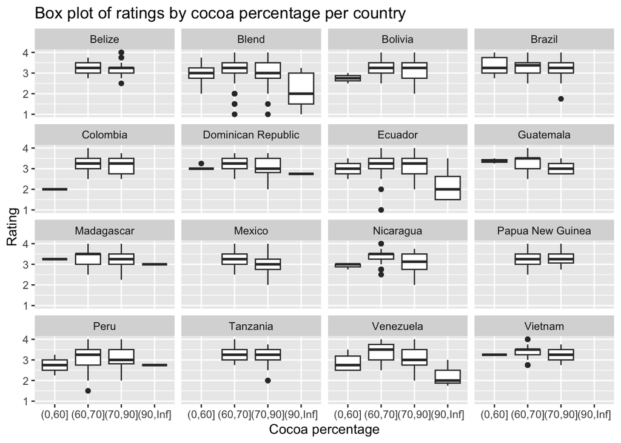

```r
cocoa_percent_num <- as.numeric(gsub("%", "", chocolate$cocoa_percent))
chocolate %>%
  mutate(cocoa_percent_cat = cut(cocoa_percent_num, breaks =
                                     c(0, 60, 70, 90, Inf))) %>%
  group_by(country_of_bean_origin) %>%
  filter(n() > 49) %>%
  ggplot(aes(x = cocoa_percent_cat, y = rating)) +
   labs(title = "Box plot of ratings by cocoa percentage per country",
       x = "Cocoa percentage",
       y = "Rating") +
  geom_boxplot() +
  facet_wrap(~ country_of_bean_origin)
```

On average, the (60,70] percentage group is most highly rated. Across the above countries, there is general agreement in the (60,70] group’s rating being higher than or similar to (70,90] group’s rating, and higher than the (0,60] and (90,Inf] group’s rating.

## Part 2: Join two datasets together

```r
#install.packages("gapminder")
library(gapminder)
gapminder_unique <- gapminder %>%
  distinct(country,continent)
join <- left_join(x = chocolate, y = gapminder_unique, by = c('country_of_bean_origin'='country'))
chocolate$continent <- join$continent
unique(chocolate$country_of_bean_origin[is.na(chocolate$continent)])
```

```
##  [1] "Fiji"                  "Burma"                 "Papua New Guinea"
##  [4] "Sao Tome"              "Vanuatu"               "Trinidad"
##  [7] "Belize"                "Blend"                 "Grenada"
## [10] "Congo"                 "Solomon Islands"       "Ivory Coast"
## [13] "Martinique"            "St. Lucia"             "U.S.A."
## [16] "St.Vincent-Grenadines" "Tobago"                "Sao Tome & Principe"
## [19] "Sumatra"               "Samoa"                 "Principe"
## [22] "Sulawesi"              "Suriname"              "DR Congo"
```

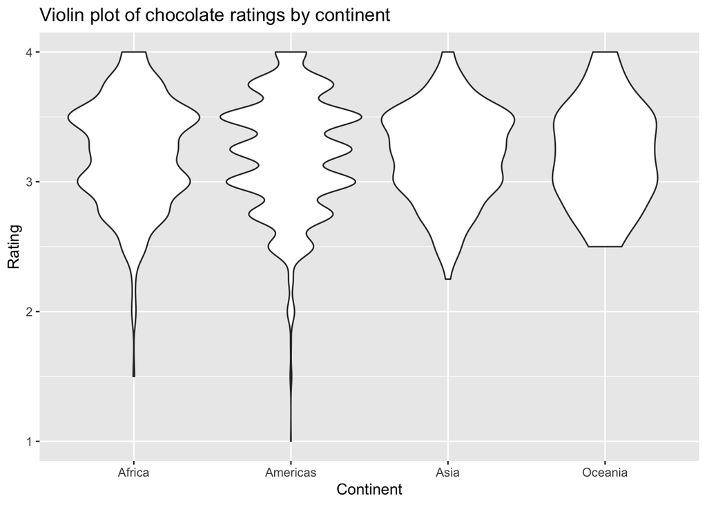

```r
chocolate <- chocolate %>%
  mutate(continent = case_when(
      is.na(continent) & country_of_bean_origin %in% c("Fiji","Papua New Guinea", "Vanuatu",
                                                       "Solomon Islands","Samoa")
      ~ "Oceania",
      is.na(continent) & country_of_bean_origin %in% c("Burma", "Sumatra")
      ~ "Asia",
      is.na(continent) & country_of_bean_origin %in% c("Sao Tome", "Congo", "Ivory Coast",
                                                       "Sao Tome & Principe", "Principe", "Sulawesi")
      ~ "Africa",
      is.na(continent) & country_of_bean_origin %in% c("Trinidad", "Belize", "Grenada", "Martinique",
                                                       "St. Lucia", "U.S.A.", "St.Vincent-Grenadines",
                                                       "Tobago", "Suriname", "DR Congo")
      ~ "Americas",
      TRUE ~ continent
    )
  )

chocolate %>%
  group_by(country_of_bean_origin) %>%
  filter(n() > 10 & country_of_bean_origin != "Blend") %>%
    ggplot(aes(
        x = continent,
        y = rating,
    )) +
  labs(title = "Violin plot of chocolate ratings by continent",
       x = "Continent",
       y = "Rating") +
    geom_violin()
```

## Part 3: Convert wide data into long data

```r
chocolate_wide <- chocolate %>%
  mutate(
    beans = ifelse(!is.na(ingredients) & str_detect(ingredients, "B"), 1, 0),
    sugar = ifelse(!is.na(ingredients) & str_detect(ingredients, "S"), 1, 0),
    cocoa_butter = ifelse(!is.na(ingredients) & str_detect(ingredients, "C"), 1, 0),
    vanilla = ifelse(!is.na(ingredients) & str_detect(ingredients, "V"), 1, 0),
    letchin = ifelse(!is.na(ingredients) & str_detect(ingredients, "L"), 1, 0),
    salt = ifelse(!is.na(ingredients) & str_detect(ingredients, "Sa"), 1, 0),
    char_cocoa = ifelse(!is.na(most_memorable_characteristics) &
                          str_detect(most_memorable_characteristics, "cocoa"), 1, 0),
    char_sweet = ifelse(!is.na(most_memorable_characteristics) &
                          str_detect(most_memorable_characteristics, "sweet"), 1, 0),
    char_nutty = ifelse(!is.na(most_memorable_characteristics) &
                          str_detect(most_memorable_characteristics, "nutty"), 1, 0),
    char_creamy = ifelse(!is.na(most_memorable_characteristics) &
                           str_detect(most_memorable_characteristics, "creamy"), 1, 0),
    char_roasty = ifelse(!is.na(most_memorable_characteristics) &
                           str_detect(most_memorable_characteristics, "roasty"), 1, 0),
    char_earthy = ifelse(!is.na(most_memorable_characteristics) &
                           str_detect(most_memorable_characteristics, "earthy"), 1, 0)
  ) %>%
  group_by(review_date) %>%
  summarize(across(11:21, mean)) %>%
  pivot_longer(-review_date, names_to = "feature", values_to = "mean_score")
chocolate_wide
```

```
## # A tibble: 176 × 3
##    review_date feature      mean_score
##          <dbl> <chr>             <dbl>
##  1        2006 beans            0.968
##  2        2006 sugar            0.968
##  3        2006 cocoa_butter     0.903
##  4        2006 vanilla          0.694
##  5        2006 letchin          0.694
##  6        2006 salt             0
##  7        2006 char_cocoa       0.210
##  8        2006 char_sweet       0.161
##  9        2006 char_nutty       0.0323
## 10        2006 char_creamy      0.242
## # … with 166 more rows
```

## Part 4: Data visualization

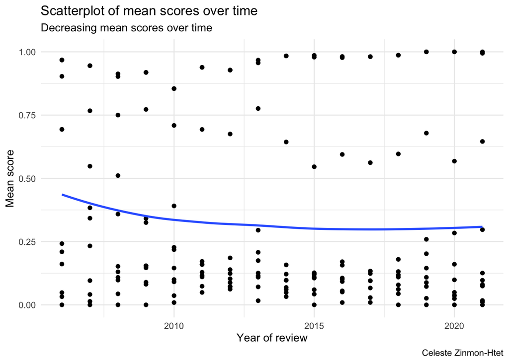

```r
chocolate_wide %>%
    ggplot(aes(review_date, mean_score)) +
    geom_point() +
    geom_smooth(
        method = "loess",
        se = FALSE
    ) +
    theme_minimal() +
  labs(title = "Scatterplot of mean scores over time",
       subtitle = "Decreasing mean scores over time",
       x = "Year of review",
       y = "Mean score",
       caption = "Celeste Zinmon-Htet")
```

## Part 5: Make the worst plot you can!

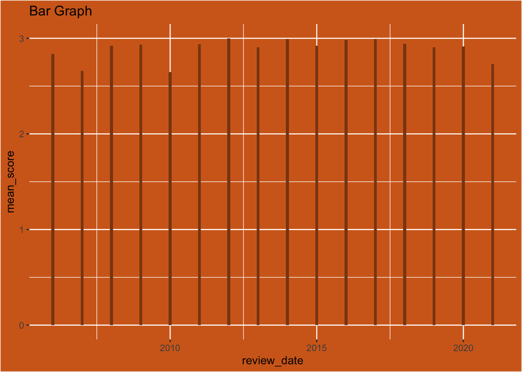

```r
chocolate_wide %>%
    ggplot(aes(review_date, mean_score)) +
  geom_bar(stat = "identity", width = 0.1, fill = "chocolate4") +
  scale_y_continuous(limits = c(0, 3)) +
  labs(title = "Bar Graph") +
  theme(
    plot.background = element_rect(fill = "chocolate"),
    panel.background = element_blank()
  )
```

1. A bar graph lumps all scores of a given year together, making it difficult to visualize the mean score for each point.
2. The title does not inform the viewer what this is a bar graph of.
3. The x and y axes are not properly labeled, and look unpolished.
4. Each bar is the same color throughout (no separation of points), which also makes it difficult to determine the actual mean score for each row of data.
5. The width of each bar is extremely thin, which is not aesthetically pleasing.
6. The y axis only goes up to 3, but the summed mean ratings go higher than that. We lose information this way.
7. The background of this graph is similar to the color of the bars, making the bars stand out less, and is somewhat distracting overall.

## Part 6: Make my plot a better plot!

Before:

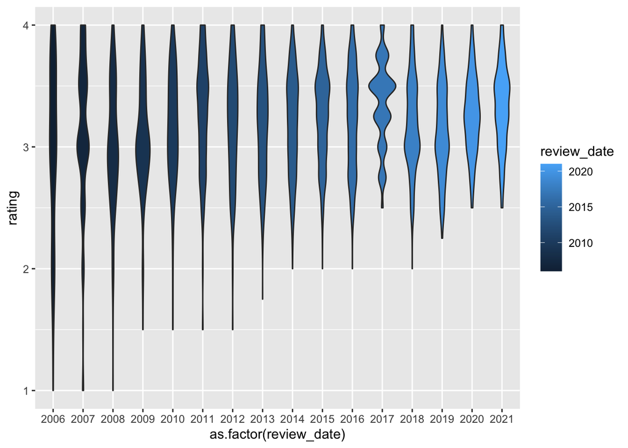

```r
chocolate %>%
    ggplot(aes(
        x = as.factor(review_date),
        y = rating,
        fill = review_date
    )) +
    geom_violin()
```

After:

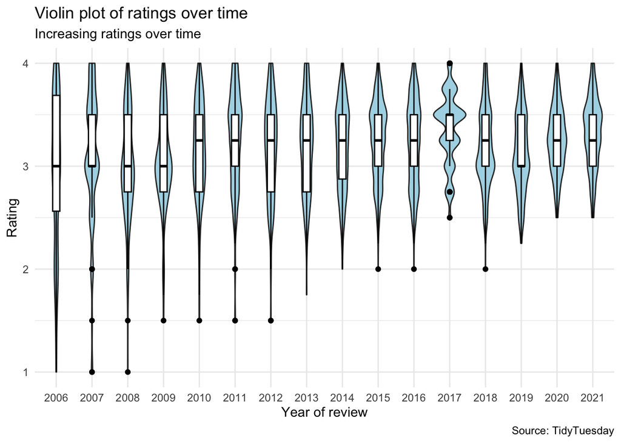

```r
chocolate %>%
    ggplot(aes(
        x = as.factor(review_date),
        y = rating
    )) +
    geom_violin(fill="lightblue") +
  labs(title = "Violin plot of ratings over time",
       subtitle = "Increasing ratings over time",
       x = "Year of review",
       y = "Rating",
       caption = "Source: TidyTuesday") +
  theme_minimal() +
  geom_boxplot(width = 0.2, position = position_dodge(0.75), color = "black", fill="white")
```

1. I replaced the different colors showing different years with a single color. While the different colors were informative as to review year, it was more distracting than helpful since there were many different colors to keep track of, and since the years are already labeled on the x-axis.
2. The x and y axes are now properly labeled. This looks a bit more polished compared to the raw variable names.
3. There was initially no title, and now there is an informative one.
4. I added a subtitle describing the trend shown in the violin plot.
5. While this is subjective, changing the theme to minimal makes this plot look cleaner.
6. I added box plots which now indicate things like the median and interquartile range.
7. A caption now lists the data source.

```r
options(width = 120)
```